# Lab 4: Coffee Lovers Unite

```python
import pandas as pd
import numpy as np
from bs4 import BeautifulSoup
import requests
```

1. Use the beautifulsoup library to scrape the data (from menuism.com like the link above) on state names and corresponding number of store locations, for the following chains: Starbucks

Dunkin’ Donuts

Peet’s Coffee & Tea

Tim Horton’s

Panera Bread

Caribou Coffee

Au Bon Pain

The Coffee Bean & Tea Leaf

McDonald’s

```python
import re
rows = []
response = requests.get("https://web.archive.org/web/20220518102911/https://www.menuism.com/restaurant-locations/dunkin-donuts-181624")
soup = BeautifulSoup(response.content, "html.parser")
for i in soup.find_all('a', title=re.compile("Starbucks Coffee locations in .*, us")):
    x = i.text.split(" Starbucks Coffee locations ")
    x[1] = x[1].strip('(').strip(')')
    rows.append({
        "State": x[0],
        "Store": "Starbucks",
        "Store Locations": x[1],
    })
```

```python
rows = []
response = requests.get("https://web.archive.org/web/20220824121240/https:/www.menuism.com/restaurant-locations/starbucks-coffee-39564")
soup = BeautifulSoup(response.content, "html.parser")
for i in soup.find_all('a', title=re.compile("Dunkin' Donuts locations in .*, us")):
    x = i.text.split(" Dunkin' Donuts locations ")
    x[1] = x[1].strip('(').strip(')')
    rows.append({
        "State": x[0],
        "Store": "Dunkin' Donuts",
        "Store Locations": x[1],
    })
```

```python
x = soup.find_all('a', title=re.compile("Starbucks Coffee locations in .*, us"))[0].text.split(" Starbucks Coffee locations ")
x[1] = x[1].strip('(').strip(')')
x
```

```
['Alaska', '24']
```

```python
coffee = pd.read_csv("df_lab4_scraped.csv")
coffee = coffee[['State', 'Coffee Chain', 'Location Count']]
coffee
```

|  | State | Coffee Chain | Location Count |
| --- | --- | --- | --- |
| 0 | Alaska | Starbucks | 24 |
| 1 | Alabama | Starbucks | 73 |
| 2 | Arkansas | Starbucks | 33 |
| 3 | Arizona | Starbucks | 279 |
| 4 | California | Starbucks | 2362 |
| ... | ... | ... | ... |
| 264 | Vermont | McDonald's | 30 |
| 265 | Washington | McDonald's | 326 |
| 266 | Wisconsin | McDonald's | 353 |
| 267 | West Virginia | McDonald's | 107 |
| 268 | Wyoming | McDonald's | 34 |

269 rows × 3 columns

2. Write a function stateabb() that takes a state name (assume it’s spelled correctly) and converts it to its state abbreviation. This can be a very simple function.

```python
def stateabb(state_name):
    states = {'Alabama': 'AL',
    'Alaska': 'AK',
    'Arizona': 'AZ',
    'Arkansas': 'AR',
    'California': 'CA',
    'Colorado': 'CO',
    'Connecticut': 'CT',
    'Delaware': 'DE',
    'Florida': 'FL',
    'Georgia': 'GA',
    'Hawaii': 'HI',
    'Idaho': 'ID',
    'Illinois': 'IL',
    'Indiana': 'IN',
    'Iowa': 'IA',
    'Kansas': 'KS',
    'Kentucky': 'KY',
    'Louisiana': 'LA',
    'Maine': 'ME',
    'Maryland': 'MD',
    'Massachusetts': 'MA',
    'Michigan': 'MI',
    'Minnesota': 'MN',
    'Mississippi': 'MS',
    'Missouri': 'MO',
    'Montana': 'MT',
    'Nebraska': 'NE',
    'Nevada': 'NV',
    'New Hampshire': 'NH',
    'New Jersey': 'NJ',
    'New Mexico': 'NM',
    'New York': 'NY',
    'North Carolina': 'NC',
    'North Dakota': 'ND',
    'Ohio': 'OH',
    'Oklahoma': 'OK',
    'Oregon': 'OR',
    'Pennsylvania': 'PA',
    'Rhode Island': 'RI',
    'South Carolina': 'SC',
    'South Dakota': 'SD',
    'Tennessee': 'TN',
    'Texas': 'TX',
    'Utah': 'UT',
    'Vermont': 'VT',
    'Virginia': 'VA',
    'Washington': 'WA',
    'West Virginia': 'WV',
    'Wisconsin': 'WI',
    'Wyoming': 'WY'}
    return states.get(state_name, "Not Found")
```

3. Parse, merge and tidy your data so that you have a row for each state and two columns: state abbrevation, location count.

```python
coffee['State Abbreviation'] = coffee['State'].apply(stateabb)
coffee.head()
```

|  | State | Coffee Chain | Location Count | State Abbreviation |
| --- | --- | --- | --- | --- |
| 0 | Alaska | Starbucks | 24 | AK |
| 1 | Alabama | Starbucks | 73 | AL |
| 2 | Arkansas | Starbucks | 33 | AR |
| 3 | Arizona | Starbucks | 279 | AZ |
| 4 | California | Starbucks | 2362 | CA |

4. Scrape the state names and populations from this wikipedia page. Convert the state names to abbreviations and merge these data with your coffee dataset.

```python
population = pd.read_html("https://simple.wikipedia.org/wiki/List_of_U.S._states_by_population", attrs = {'class': 'wikitable sortable', "style": "width:100%; text-align:center;"})[0]
pop = population[['State','Census population, April 1, 2020 [1][2]']]
pop = pop.rename(columns = {'Census population, April 1, 2020 [1][2]': 'Population'})
```

```python
pop['State'] = pop['State'].apply(stateabb)
```

```python
pop = pop[pop["State"] != 'Not Found']
pop.sort_values('State').head()
```

|  | State | Population |
| --- | --- | --- |
| 48 | AK | 733391 |
| 23 | AL | 5024279 |
| 33 | AR | 3011524 |
| 13 | AZ | 7151502 |
| 0 | CA | 39538223 |

```python
combined = coffee.merge(pop, how='left', left_on='State Abbreviation', right_on='State')
combined = combined[['State_x', 'Coffee Chain', 'Location Count', 'State Abbreviation', 'Population']].rename(columns={'State_x': 'State'})
combined = combined[combined['State Abbreviation'] != "Not Found"]
combined.head()
```

|  | State | Coffee Chain | Location Count | State Abbreviation | Population |
| --- | --- | --- | --- | --- | --- |
| 0 | Alaska | Starbucks | 24 | AK | 733391.0 |
| 1 | Alabama | Starbucks | 73 | AL | 5024279.0 |
| 2 | Arkansas | Starbucks | 33 | AR | 3011524.0 |
| 3 | Arizona | Starbucks | 279 | AZ | 7151502.0 |
| 4 | California | Starbucks | 2362 | CA | 39538223.0 |

5. Find the revenue, stock price, or your financial metric of choice for each of the companies listed above (if you can find a website to scrape these from that’s great!…but it’s okay if you manually enter these into R). Merge these values into your big dataset. Note: these values may be repeated for each state.

```python
def revenue(coffee_co):
    rev = {'Starbucks': 32250000000, "Dunkin' Donuts": 1370000000, "Peet's Coffee & Tea": 983000000, "Tim Horton's": 3340000000, "Panera Bread": 5795000000, "Caribou Coffee": 262000000, "Au Bon Pain": 351000000, "The Coffee Bean & Tea Leaf": 500000000, "McDonald's": 23223000000}
    return rev.get(coffee_co)
```

```python
combined['Revenue'] = combined['Coffee Chain'].apply(revenue)
```

6. Create a region variable in your dataset according to the scheme on this wikipedia page: Northeast, Midwest, South, West. You do not need to scrape this information.

```python
def region(state_name):
    region = {
    "Connecticut": "Northeast",
    "Maine": "Northeast",
    "Massachusetts": "Northeast",
    "New Hampshire": "Northeast",
    "Rhode Island": "Northeast",
    "Vermont": "Northeast",
    "New Jersey": "Northeast",
    "New York": "Northeast",
    "Pennsylvania": "Northeast",
    "Illinois": "Midwest",
    "Indiana": "Midwest",
    "Michigan": "Midwest",
    "Ohio": "Midwest",
    "Wisconsin": "Midwest",
    "Iowa": "Midwest",
    "Kansas": "Midwest",
    "Minnesota": "Midwest",
    "Missouri": "Midwest",
    "Nebraska": "Midwest",
    "North Dakota": "Midwest",
    "South Dakota": "Midwest",
    "Delaware": "South",
    "Florida": "South",
    "Georgia": "South",
    "Maryland": "South",
    "North Carolina": "South",
    "South Carolina": "South",
    "Virginia": "South",
    "Washington, D.C.": "South",
    "West Virginia": "South",
    "Alabama": "South",
    "Kentucky": "South",
    "Mississippi": "South",
    "Tennessee": "South",
    "Arkansas": "South",
    "Louisiana": "South",
    "Oklahoma": "South",
    "Texas": "South",
    "Arizona": "West",
    "Colorado": "West",
    "Idaho": "West",
    "Montana": "West",
    "Nevada": "West",
    "New Mexico": "West",
    "Utah": "West",
    "Wyoming": "West",
    "Alaska": "West",
    "California": "West",
    "Hawaii": "West",
    "Oregon": "West",
    "Washington": "West"}
    return region.get(state_name)
```

```python
combined['Region'] = combined['State'].apply(region)
combined.head()
```

|  | State | Coffee Chain | Location Count | State Abbreviation | Population | Revenue | Region |
| --- | --- | --- | --- | --- | --- | --- | --- |
| 0 | Alaska | Starbucks | 24 | AK | 733391.0 | 32250000000 | West |
| 1 | Alabama | Starbucks | 73 | AL | 5024279.0 | 32250000000 | South |
| 2 | Arkansas | Starbucks | 33 | AR | 3011524.0 | 32250000000 | South |
| 3 | Arizona | Starbucks | 279 | AZ | 7151502.0 | 32250000000 | West |
| 4 | California | Starbucks | 2362 | CA | 39538223.0 | 32250000000 | West |

Assess and comment on the prevalence of each chain. Some questions to consider (you don’t need to answer all of these and you may come up with your own): Are some of these chains more prevalent in certain states than others? Possibly despite having less stores overall? Same questions for regions instead of states.

How does your chosen financial metric change by state and region for each chain? For example, having 5 stores in California is very different from having 5 stores in Wyoming.

Does the distribution of each chain’s stores match population distribution, by both state/region?

Do the financial data match what you’d expect based on the number and locations of the stores? Why or why not?

Are some of these chains more prevalent in certain states than others? Possibly despite having less stores overall? Same questions for regions instead of states.

```python
combined.groupby("State").sum().sort_values("Location Count")
```

| State | Location Count | Population | Revenue |
| --- | --- | --- | --- |
| Wyoming | 50 | 1153702.0 | 55473000000 |
| North Dakota | 53 | 3116376.0 | 61530000000 |
| South Dakota | 56 | 3546668.0 | 61530000000 |
| Alaska | 57 | 1466782.0 | 55473000000 |
| Montana | 75 | 2168450.0 | 55473000000 |
| Vermont | 76 | 2572308.0 | 62638000000 |
| Delaware | 133 | 4949740.0 | 65978000000 |
| Idaho | 135 | 5517318.0 | 61268000000 |
| West Virginia | 146 | 8968580.0 | 65978000000 |
| Nebraska | 149 | 9807520.0 | 62900000000 |
| Hawaii | 170 | 7276355.0 | 58326000000 |
| New Mexico | 174 | 8470088.0 | 62638000000 |
| Mississippi | 195 | 11845116.0 | 62638000000 |
| Utah | 211 | 9814848.0 | 56843000000 |
| Maine | 229 | 8174154.0 | 66329000000 |
| Arkansas | 247 | 12046096.0 | 62638000000 |
| Rhode Island | 249 | 6584274.0 | 66329000000 |
| Iowa | 282 | 15951845.0 | 62900000000 |
| Kansas | 297 | 14689400.0 | 62900000000 |
| New Hampshire | 297 | 6887645.0 | 62989000000 |
| Oklahoma | 316 | 15837412.0 | 62638000000 |
| South Carolina | 355 | 20473700.0 | 62638000000 |
| Alabama | 373 | 20097116.0 | 62638000000 |
| Louisiana | 373 | 18631028.0 | 62638000000 |
| Nevada | 414 | 21732298.0 | 64472000000 |
| Kentucky | 420 | 27035016.0 | 66329000000 |
| Oregon | 510 | 25423536.0 | 63883000000 |
| Wisconsin | 565 | 29468590.0 | 62900000000 |
| Tennessee | 632 | 27643360.0 | 62638000000 |
| Missouri | 632 | 43084391.0 | 66591000000 |
| Colorado | 657 | 34642284.0 | 63883000000 |
| Indiana | 717 | 47498696.0 | 66591000000 |
| Arizona | 727 | 35757510.0 | 63138000000 |
| Connecticut | 745 | 21635664.0 | 66329000000 |
| North Carolina | 798 | 62636328.0 | 63400000000 |
| Minnesota | 827 | 39945458.0 | 66591000000 |
| Maryland | 902 | 37063344.0 | 63251000000 |
| Washington | 992 | 38526405.0 | 63621000000 |
| Virginia | 1048 | 60419751.0 | 66591000000 |
| Georgia | 1059 | 74983356.0 | 63751000000 |
| New Jersey | 1076 | 55733964.0 | 66329000000 |
| Michigan | 1284 | 70541317.0 | 66591000000 |
| Pennsylvania | 1440 | 104021600.0 | 67574000000 |
| Ohio | 1556 | 82596136.0 | 66591000000 |
| Massachusetts | 1764 | 42179502.0 | 66329000000 |
| Illinois | 2095 | 89687556.0 | 64234000000 |
| Texas | 2250 | 204018535.0 | 64472000000 |
| New York | 2621 | 121207494.0 | 66329000000 |
| Florida | 2663 | 129229122.0 | 63489000000 |
| California | 4585 | 237229338.0 | 64121000000 |

```python
combined.groupby("Coffee Chain").sum().sort_values('Location Count')
```

| Coffee Chain | Location Count | Population | Revenue |
| --- | --- | --- | --- |
| Peet's Coffee & Tea | 197 | 116775072.0 | 8847000000 |
| The Coffee Bean & Tea Leaf | 248 | 123084598.0 | 4000000000 |
| Au Bon Pain | 311 | 194116960.0 | 7371000000 |
| Tim Horton's | 500 | 112033149.0 | 53440000000 |
| Caribou Coffee | 615 | 127959037.0 | 4978000000 |
| Panera Bread | 2374 | 323638382.0 | 260775000000 |
| Dunkin' Donuts | 6466 | 324860402.0 | 60280000000 |
| Starbucks | 10222 | 330759736.0 | 1612500000000 |
| McDonald's | 16744 | 330759736.0 | 1161150000000 |

```python
combined[combined['Coffee Chain'] == 'Starbucks'].sort_values("Location Count")
```

|  | State | Coffee Chain | Location Count | State Abbreviation | Population | Revenue | Region |
| --- | --- | --- | --- | --- | --- | --- | --- |
| 46 | Vermont | Starbucks | 6 | VT | 643077.0 | 32250000000 | Northeast |
| 49 | West Virginia | Starbucks | 13 | WV | 1793716.0 | 32250000000 | South |
| 41 | South Dakota | Starbucks | 14 | SD | 886667.0 | 32250000000 | Midwest |
| 28 | North Dakota | Starbucks | 15 | ND | 779094.0 | 32250000000 | Midwest |
| 50 | Wyoming | Starbucks | 16 | WY | 576851.0 | 32250000000 | West |
| 26 | Montana | Starbucks | 17 | MT | 1084225.0 | 32250000000 | West |
| 8 | Delaware | Starbucks | 20 | DE | 989948.0 | 32250000000 | South |
| 39 | Rhode Island | Starbucks | 21 | RI | 1097379.0 | 32250000000 | Northeast |
| 30 | New Hampshire | Starbucks | 22 | NH | 1377529.0 | 32250000000 | Northeast |
| 21 | Maine | Starbucks | 22 | ME | 1362359.0 | 32250000000 | Northeast |
| 25 | Mississippi | Starbucks | 23 | MS | 2961279.0 | 32250000000 | South |
| 0 | Alaska | Starbucks | 24 | AK | 733391.0 | 32250000000 | West |
| 29 | Nebraska | Starbucks | 30 | NE | 1961504.0 | 32250000000 | Midwest |
| 2 | Arkansas | Starbucks | 33 | AR | 3011524.0 | 32250000000 | South |
| 12 | Iowa | Starbucks | 49 | IA | 3190369.0 | 32250000000 | Midwest |
| 32 | New Mexico | Starbucks | 56 | NM | 2117522.0 | 32250000000 | West |
| 13 | Idaho | Starbucks | 57 | ID | 1839106.0 | 32250000000 | West |
| 44 | Utah | Starbucks | 59 | UT | 3271616.0 | 32250000000 | West |
| 36 | Oklahoma | Starbucks | 62 | OK | 3959353.0 | 32250000000 | South |
| 16 | Kansas | Starbucks | 65 | KS | 2937880.0 | 32250000000 | Midwest |
| 40 | South Carolina | Starbucks | 65 | SC | 5118425.0 | 32250000000 | South |
| 17 | Kentucky | Starbucks | 69 | KY | 4505836.0 | 32250000000 | South |
| 11 | Hawaii | Starbucks | 72 | HI | 1455271.0 | 32250000000 | West |
| 1 | Alabama | Starbucks | 73 | AL | 5024279.0 | 32250000000 | South |
| 18 | Louisiana | Starbucks | 76 | LA | 4657757.0 | 32250000000 | South |
| 6 | Connecticut | Starbucks | 107 | CT | 3605944.0 | 32250000000 | Northeast |
| 24 | Missouri | Starbucks | 118 | MO | 6154913.0 | 32250000000 | Midwest |
| 48 | Wisconsin | Starbucks | 119 | WI | 5893718.0 | 32250000000 | Midwest |
| 42 | Tennessee | Starbucks | 126 | TN | 6910840.0 | 32250000000 | South |
| 23 | Minnesota | Starbucks | 140 | MN | 5706494.0 | 32250000000 | Midwest |
| 31 | New Jersey | Starbucks | 154 | NJ | 9288994.0 | 32250000000 | Northeast |
| 27 | North Carolina | Starbucks | 181 | NC | 10439388.0 | 32250000000 | South |
| 33 | Nevada | Starbucks | 188 | NV | 3104614.0 | 32250000000 | West |
| 15 | Indiana | Starbucks | 193 | IN | 6785528.0 | 32250000000 | Midwest |
| 22 | Michigan | Starbucks | 196 | MI | 10077331.0 | 32250000000 | Midwest |
| 19 | Massachusetts | Starbucks | 208 | MA | 7029917.0 | 32250000000 | Northeast |
| 20 | Maryland | Starbucks | 212 | MD | 6177224.0 | 32250000000 | South |
| 10 | Georgia | Starbucks | 248 | GA | 10711908.0 | 32250000000 | South |
| 35 | Ohio | Starbucks | 266 | OH | 11799448.0 | 32250000000 | Midwest |
| 37 | Oregon | Starbucks | 279 | OR | 4237256.0 | 32250000000 | West |
| 38 | Pennsylvania | Starbucks | 279 | PA | 13002700.0 | 32250000000 | Northeast |
| 3 | Arizona | Starbucks | 279 | AZ | 7151502.0 | 32250000000 | West |
| 45 | Virginia | Starbucks | 300 | VA | 8631393.0 | 32250000000 | South |
| 5 | Colorado | Starbucks | 371 | CO | 5773714.0 | 32250000000 | West |
| 14 | Illinois | Starbucks | 455 | IL | 12812508.0 | 32250000000 | Midwest |
| 34 | New York | Starbucks | 492 | NY | 20201249.0 | 32250000000 | Northeast |
| 9 | Florida | Starbucks | 616 | FL | 21538187.0 | 32250000000 | South |
| 47 | Washington | Starbucks | 634 | WA | 7705281.0 | 32250000000 | West |
| 43 | Texas | Starbucks | 720 | TX | 29145505.0 | 32250000000 | South |
| 4 | California | Starbucks | 2362 | CA | 39538223.0 | 32250000000 | West |

```python
combined[combined['Coffee Chain'] == "Panera Bread"].sort_values("Location Count")
```

|  | State | Coffee Chain | Location Count | State Abbreviation | Population | Revenue | Region |
| --- | --- | --- | --- | --- | --- | --- | --- |
| 138 | Louisiana | Panera Bread | 1 | LA | 4657757.0 | 5795000000 | South |
| 160 | South Dakota | Panera Bread | 2 | SD | 886667.0 | 5795000000 | Midwest |
| 147 | North Dakota | Panera Bread | 2 | ND | 779094.0 | 5795000000 | Midwest |
| 145 | Mississippi | Panera Bread | 4 | MS | 2961279.0 | 5795000000 | South |
| 151 | New Mexico | Panera Bread | 5 | NM | 2117522.0 | 5795000000 | West |
| 141 | Maine | Panera Bread | 5 | ME | 1362359.0 | 5795000000 | Northeast |
| 164 | Vermont | Panera Bread | 6 | VT | 643077.0 | 5795000000 | Northeast |
| 152 | Nevada | Panera Bread | 6 | NV | 3104614.0 | 5795000000 | West |
| 133 | Idaho | Panera Bread | 7 | ID | 1839106.0 | 5795000000 | West |
| 158 | Rhode Island | Panera Bread | 9 | RI | 1097379.0 | 5795000000 | Northeast |
| 129 | Delaware | Panera Bread | 9 | DE | 989948.0 | 5795000000 | South |
| 156 | Oregon | Panera Bread | 12 | OR | 4237256.0 | 5795000000 | West |
| 149 | New Hampshire | Panera Bread | 12 | NH | 1377529.0 | 5795000000 | Northeast |
| 123 | Arkansas | Panera Bread | 13 | AR | 3011524.0 | 5795000000 | South |
| 167 | West Virginia | Panera Bread | 14 | WV | 1793716.0 | 5795000000 | South |
| 148 | Nebraska | Panera Bread | 15 | NE | 1961504.0 | 5795000000 | Midwest |
| 165 | Washington | Panera Bread | 16 | WA | 7705281.0 | 5795000000 | West |
| 159 | South Carolina | Panera Bread | 17 | SC | 5118425.0 | 5795000000 | South |
| 122 | Alabama | Panera Bread | 20 | AL | 5024279.0 | 5795000000 | South |
| 132 | Iowa | Panera Bread | 27 | IA | 3190369.0 | 5795000000 | Midwest |
| 136 | Kansas | Panera Bread | 27 | KS | 2937880.0 | 5795000000 | Midwest |
| 155 | Oklahoma | Panera Bread | 28 | OK | 3959353.0 | 5795000000 | South |
| 124 | Arizona | Panera Bread | 29 | AZ | 7151502.0 | 5795000000 | West |
| 137 | Kentucky | Panera Bread | 30 | KY | 4505836.0 | 5795000000 | South |
| 126 | Colorado | Panera Bread | 32 | CO | 5773714.0 | 5795000000 | West |
| 127 | Connecticut | Panera Bread | 41 | CT | 3605944.0 | 5795000000 | Northeast |
| 161 | Tennessee | Panera Bread | 42 | TN | 6910840.0 | 5795000000 | South |
| 166 | Wisconsin | Panera Bread | 47 | WI | 5893718.0 | 5795000000 | Midwest |
| 146 | North Carolina | Panera Bread | 52 | NC | 10439388.0 | 5795000000 | South |
| 143 | Minnesota | Panera Bread | 52 | MN | 5706494.0 | 5795000000 | Midwest |
| 135 | Indiana | Panera Bread | 53 | IN | 6785528.0 | 5795000000 | Midwest |
| 140 | Maryland | Panera Bread | 69 | MD | 6177224.0 | 5795000000 | South |
| 131 | Georgia | Panera Bread | 71 | GA | 10711908.0 | 5795000000 | South |
| 139 | Massachusetts | Panera Bread | 77 | MA | 7029917.0 | 5795000000 | Northeast |
| 144 | Missouri | Panera Bread | 91 | MO | 6154913.0 | 5795000000 | Midwest |
| 150 | New Jersey | Panera Bread | 98 | NJ | 9288994.0 | 5795000000 | Northeast |
| 163 | Virginia | Panera Bread | 98 | VA | 8631393.0 | 5795000000 | South |
| 142 | Michigan | Panera Bread | 108 | MI | 10077331.0 | 5795000000 | Midwest |
| 162 | Texas | Panera Bread | 110 | TX | 29145505.0 | 5795000000 | South |
| 157 | Pennsylvania | Panera Bread | 112 | PA | 13002700.0 | 5795000000 | Northeast |
| 153 | New York | Panera Bread | 138 | NY | 20201249.0 | 5795000000 | Northeast |
| 134 | Illinois | Panera Bread | 154 | IL | 12812508.0 | 5795000000 | Midwest |
| 154 | Ohio | Panera Bread | 170 | OH | 11799448.0 | 5795000000 | Midwest |
| 125 | California | Panera Bread | 216 | CA | 39538223.0 | 5795000000 | West |
| 130 | Florida | Panera Bread | 227 | FL | 21538187.0 | 5795000000 | South |

```python
combined[combined["Coffee Chain"] == 'Au Bon Pain'].sort_values("Location Count")
```

|  | State | Coffee Chain | Location Count | State Abbreviation | Population | Revenue | Region |
| --- | --- | --- | --- | --- | --- | --- | --- |
| 203 | Nevada | Au Bon Pain | 1 | NV | 3104614.0 | 351000000 | West |
| 194 | Kentucky | Au Bon Pain | 1 | KY | 4505836.0 | 351000000 | South |
| 197 | Maine | Au Bon Pain | 1 | ME | 1362359.0 | 351000000 | Northeast |
| 191 | Georgia | Au Bon Pain | 3 | GA | 10711908.0 | 351000000 | South |
| 200 | Missouri | Au Bon Pain | 3 | MO | 6154913.0 | 351000000 | Midwest |
| 199 | Minnesota | Au Bon Pain | 5 | MN | 5706494.0 | 351000000 | Midwest |
| 207 | Rhode Island | Au Bon Pain | 6 | RI | 1097379.0 | 351000000 | Northeast |
| 201 | New Hampshire | Au Bon Pain | 6 | NH | 1377529.0 | 351000000 | Northeast |
| 198 | Michigan | Au Bon Pain | 6 | MI | 10077331.0 | 351000000 | Midwest |
| 188 | Connecticut | Au Bon Pain | 8 | CT | 3605944.0 | 351000000 | Northeast |
| 193 | Indiana | Au Bon Pain | 8 | IN | 6785528.0 | 351000000 | Midwest |
| 196 | Maryland | Au Bon Pain | 9 | MD | 6177224.0 | 351000000 | South |
| 202 | New Jersey | Au Bon Pain | 10 | NJ | 9288994.0 | 351000000 | Northeast |
| 205 | Ohio | Au Bon Pain | 10 | OH | 11799448.0 | 351000000 | Midwest |
| 209 | Virginia | Au Bon Pain | 10 | VA | 8631393.0 | 351000000 | South |
| 208 | Texas | Au Bon Pain | 16 | TX | 29145505.0 | 351000000 | South |
| 190 | Florida | Au Bon Pain | 23 | FL | 21538187.0 | 351000000 | South |
| 206 | Pennsylvania | Au Bon Pain | 28 | PA | 13002700.0 | 351000000 | Northeast |
| 192 | Illinois | Au Bon Pain | 32 | IL | 12812508.0 | 351000000 | Midwest |
| 204 | New York | Au Bon Pain | 58 | NY | 20201249.0 | 351000000 | Northeast |
| 195 | Massachusetts | Au Bon Pain | 67 | MA | 7029917.0 | 351000000 | Northeast |

```python
combined[combined['Coffee Chain'] == "Caribou Coffee"].sort_values("Location Count")
```

|  | State | Coffee Chain | Location Count | State Abbreviation | Population | Revenue | Region |
| --- | --- | --- | --- | --- | --- | --- | --- |
| 183 | Oregon | Caribou Coffee | 1 | OR | 4237256.0 | 262000000 | West |
| 173 | Indiana | Caribou Coffee | 1 | IN | 6785528.0 | 262000000 | Midwest |
| 178 | Missouri | Caribou Coffee | 2 | MO | 6154913.0 | 262000000 | Midwest |
| 185 | South Dakota | Caribou Coffee | 4 | SD | 886667.0 | 262000000 | Midwest |
| 174 | Kansas | Caribou Coffee | 5 | KS | 2937880.0 | 262000000 | Midwest |
| 181 | Nebraska | Caribou Coffee | 5 | NE | 1961504.0 | 262000000 | Midwest |
| 184 | Pennsylvania | Caribou Coffee | 6 | PA | 13002700.0 | 262000000 | Northeast |
| 180 | North Dakota | Caribou Coffee | 7 | ND | 779094.0 | 262000000 | Midwest |
| 168 | Colorado | Caribou Coffee | 9 | CO | 5773714.0 | 262000000 | West |
| 175 | Maryland | Caribou Coffee | 9 | MD | 6177224.0 | 262000000 | South |
| 171 | Iowa | Caribou Coffee | 11 | IA | 3190369.0 | 262000000 | Midwest |
| 187 | Wisconsin | Caribou Coffee | 16 | WI | 5893718.0 | 262000000 | Midwest |
| 186 | Virginia | Caribou Coffee | 19 | VA | 8631393.0 | 262000000 | South |
| 170 | Georgia | Caribou Coffee | 25 | GA | 10711908.0 | 262000000 | South |
| 179 | North Carolina | Caribou Coffee | 26 | NC | 10439388.0 | 262000000 | South |
| 176 | Michigan | Caribou Coffee | 30 | MI | 10077331.0 | 262000000 | Midwest |
| 182 | Ohio | Caribou Coffee | 46 | OH | 11799448.0 | 262000000 | Midwest |
| 172 | Illinois | Caribou Coffee | 81 | IL | 12812508.0 | 262000000 | Midwest |
| 177 | Minnesota | Caribou Coffee | 312 | MN | 5706494.0 | 262000000 | Midwest |

Are some of these chains more prevalent in certain states than others? Possibly despite having less stores overall?

Minnesota has 312 locations of Caribou Coffee which is more than all of the other states combined. Minnesota has 52 Panera’s and 140 Starbuck’s coffees. Both of these are much larger companies with many more locations overall, but in Minnesota, Caribou Coffee is king.

```python
combined.groupby('Region').sum()
```

| Region | Location Count | Population | Revenue |
| --- | --- | --- | --- |
| Midwest | 8513 | 449933953.0 | 771849000000 |
| Northeast | 8497 | 368996605.0 | 591175000000 |
| South | 11910 | 735877600.0 | 1021705000000 |
| West | 8757 | 429178914.0 | 788612000000 |

```python
combined[combined['Coffee Chain'] == 'Starbucks'].groupby('Region').sum().sort_values("Location Count")
```

| Region | Location Count | Population | Revenue |
| --- | --- | --- | --- |
| Northeast | 1311 | 57609148.0 | 290250000000 |
| Midwest | 1660 | 68985454.0 | 387000000000 |
| South | 2837 | 125576562.0 | 516000000000 |
| West | 4414 | 78588572.0 | 419250000000 |

```python
combined[combined['Coffee Chain'] == "Dunkin' Donuts"].groupby('Region').sum().sort_values("Location Count")
```

| Region | Location Count | Population | Revenue |
| --- | --- | --- | --- |
| West | 169 | 74354999.0 | 12330000000 |
| Midwest | 929 | 67319693.0 | 13700000000 |
| South | 1497 | 125576562.0 | 21920000000 |
| Northeast | 3871 | 57609148.0 | 12330000000 |

Are some of these chains more prevalent in certain Regions than others? Possibly despite having less stores overall?

Yes, Dunkin Donuts is more prevalent in the Northeast than in any other region. Dunkin Donuts has less stores than McDonald’s and Starbucks yet they still dominate the Northeast with the highest amount of stores by far.

[figure not shown]

[output not shown]

```python
from plotnine import ggplot, aes, geom_point, theme
```

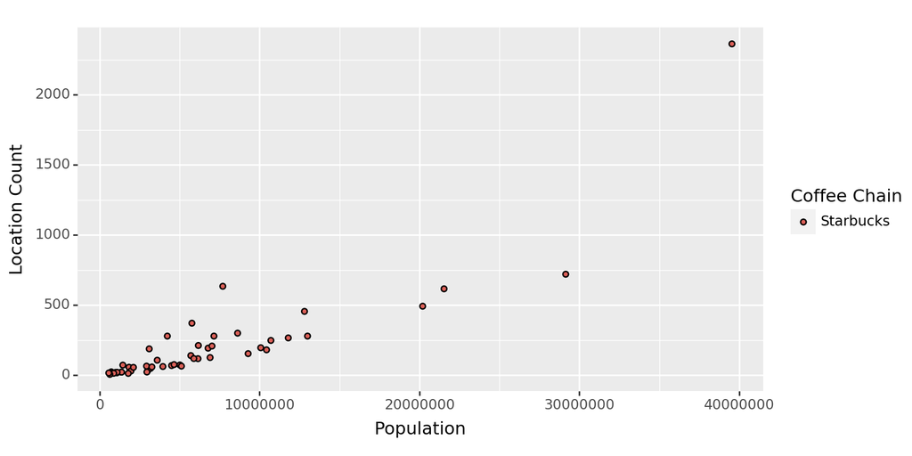

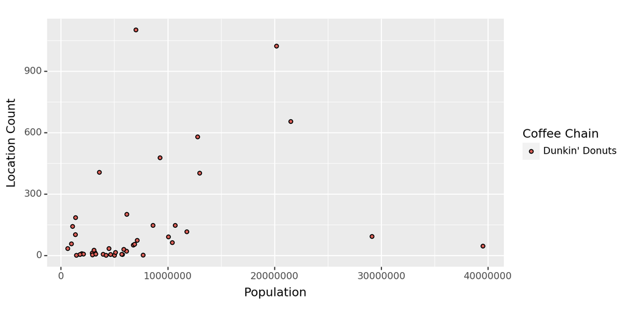

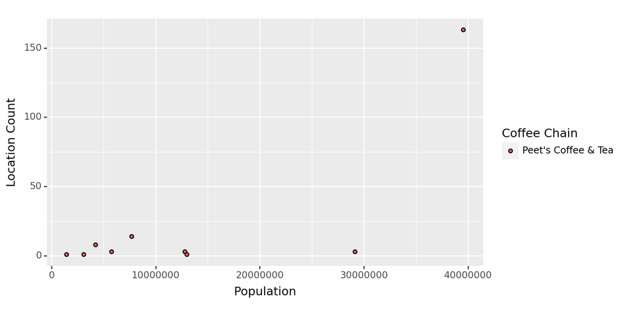

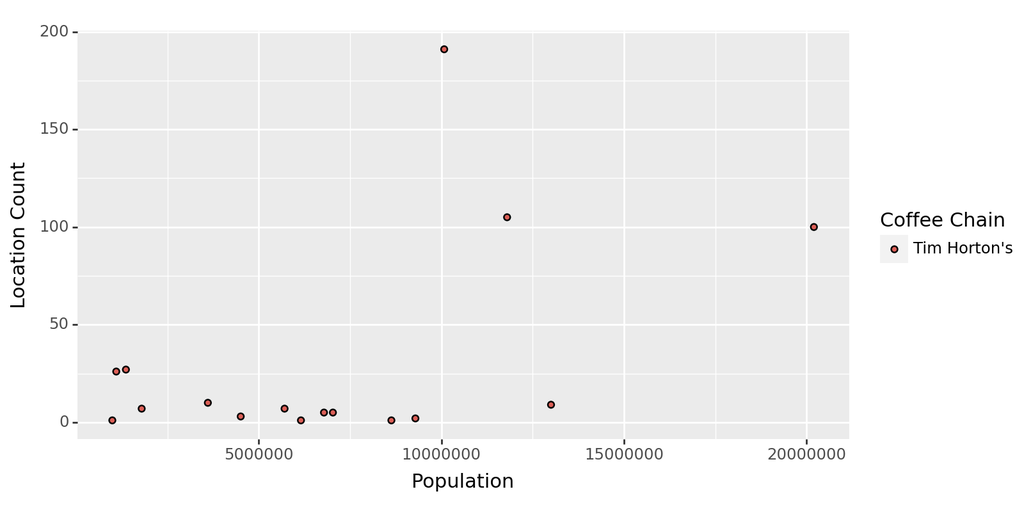

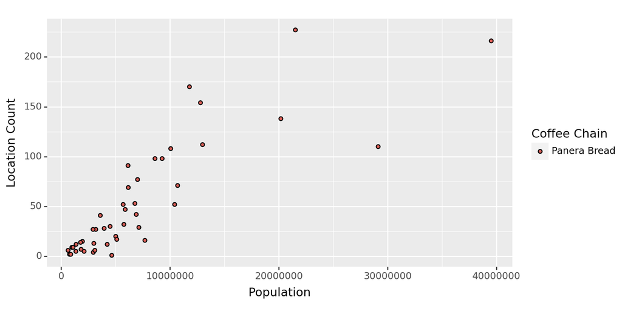

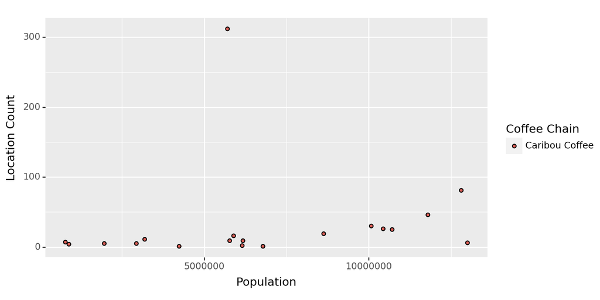

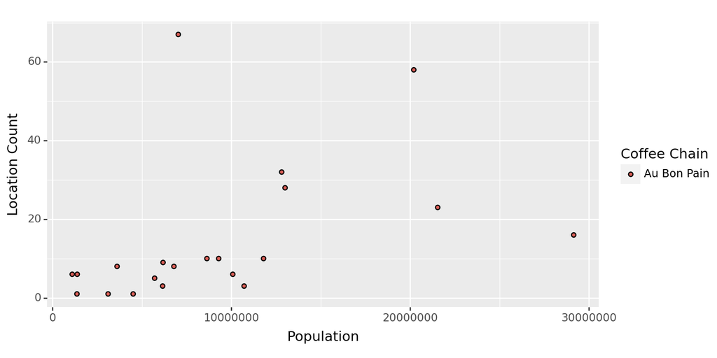

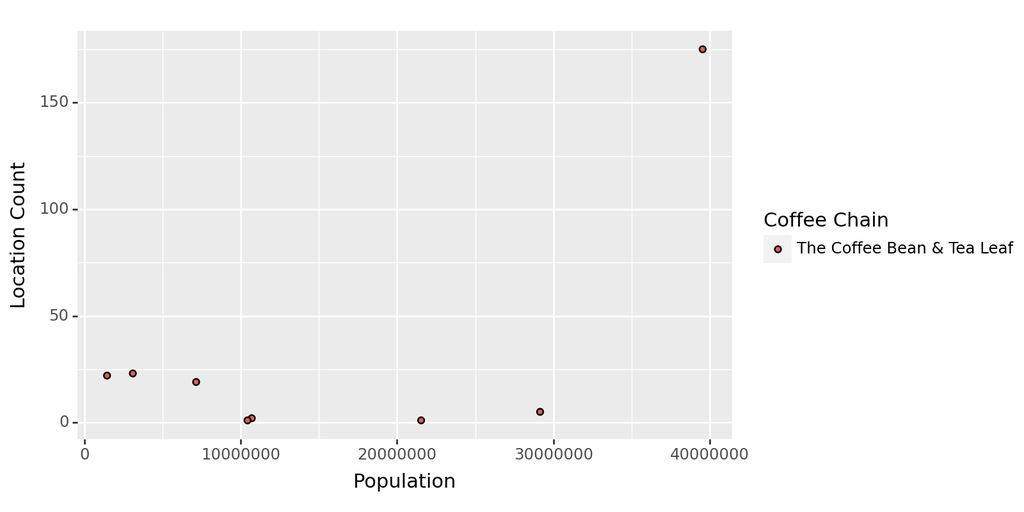

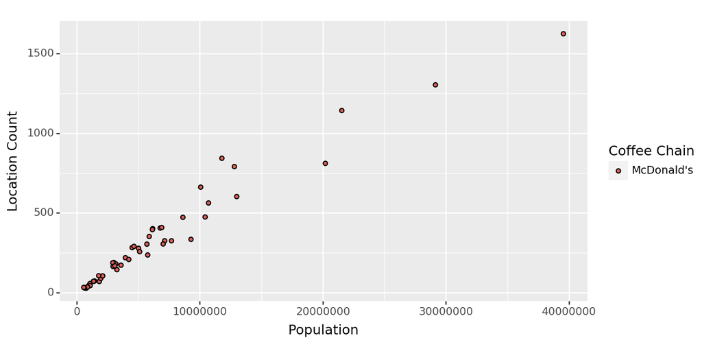

```python
for i in combined['Coffee Chain'].unique():
    plot = (
    ggplot(combined[combined['Coffee Chain'] == i])
    + aes(x='Population', y = 'Location Count', fill = 'Coffee Chain')
    + geom_point()

    + theme(figure_size=(8, 4))
    )
    print(plot)
```

For the most part, as population increases, so does the number of locations per coffee chain. McDonald’s has the most linear increase in location count as population increases. The Coffee Bean does not strictly increase and neither does Peet’s Coffee.

Automate: Convert your code for Exercises 1-3 above to a function that takes a single argument: the menuism URL. This function should

Scrape the information on state names and corresponding number of store locations on the webpage specified

Extract the name of the company from either the URL specified or the webpage

Return a clean, organized dataset that has three columns: state abbreviation, location count, company name. Company name will likely be repeated on every row.

```python
def coffee_scraper(URL):
    for i in ['Starbucks', "Dunkin' Donuts", "Peet's Coffee & Tea", "Tim Horton's", 'Panera Bread', 'Caribou Coffee', 'Au Bon Pain','The Coffee Bean & Tea Leaf', "McDonald's"]:
        response = requests.get(url)
        soup = BeautifulSoup(response.content, "html.parser")
        soup.find_all('div',{"class": "a"})[0]

#Add the ending url for each coffee shop to the end of the url for the menuism site and repeat for each coffee shop. Call the state abbreviation function on the scrapped data to get the abbreviation and then return the scrapped data.
```